# Key Ideas

August 20, 2018

## Introduction

[figure not shown]

## What is Economics?

[video not shown]

## What is Economics?

At the core, economics is:

- the stock market
- business
- **individual choice**
- **how individual choice aggregates to social behaviors and policies**

## Micro vs. Macro

- Micro is the study of individual and firm choice.
  - “Do I make coffee or go to starbucks for a mocha?”
  - “What price should we charge for our new model of running shoe?”
- Macro is the study of how individual decisions aggregate and affect society as a whole.
  - “How is employment affected by the minimum wage?”
  - “How does trade with China affect the U.S.?”

## Economics has five key ideas:

- Scarcity
- Opportunity Cost
- Marginality
- We make choices to satisfy our self-interest
- Specialization

## What is Scarcity?

- Resources for which supply is limited for the amount desired/demanded

**Land** – **Labor** – **Infrastructure** – **Human Capital** – **Capital**

*What Else?*

## Opportunity Cost

[video not shown]

## Opportunity Cost

- What you must give up in making your choice
- Opportunity cost can be said to be the “true cost” of your choice.

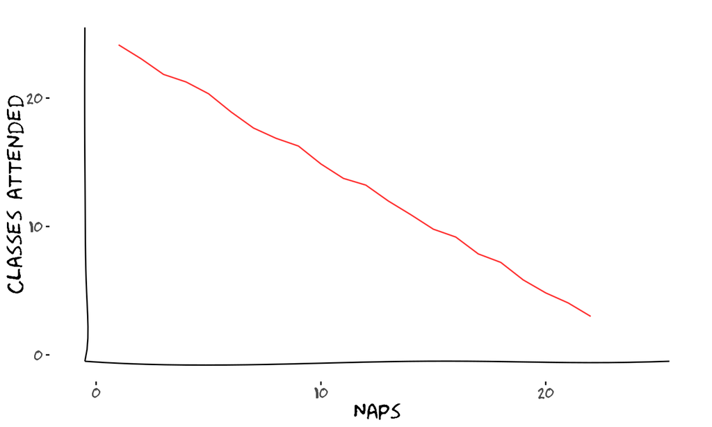

## Marginality

[video not shown]

## Marginality

- Marginality is the value of each additional unit of production or consumption

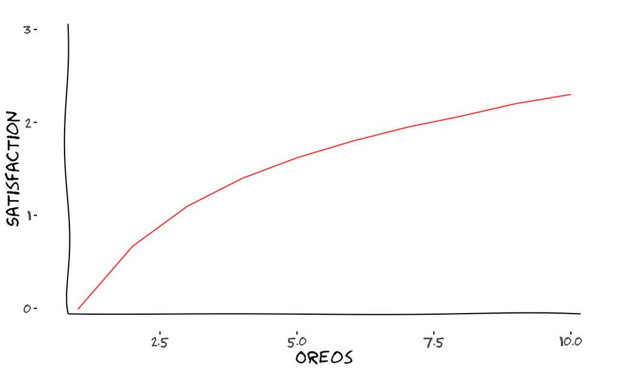

## Choices are made to satisfy our self-interest

[interactive chart not shown]

[via GIPHY](https://giphy.com/gifs/funny-loki-thor-z4bVNnaFUPtQI)

## Choices are made to satisfy our self-interest

- Not necessarily selfish: altruistic behavior may be in our own self-interest if we care about the well-being of others

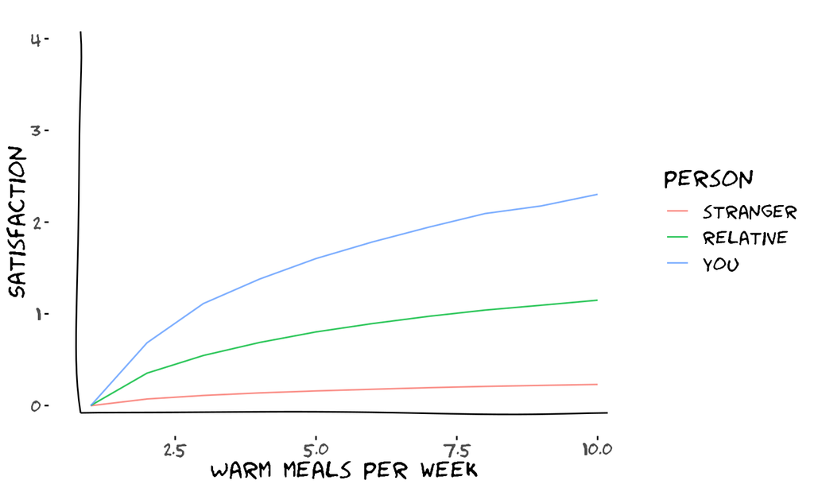

## Specialization

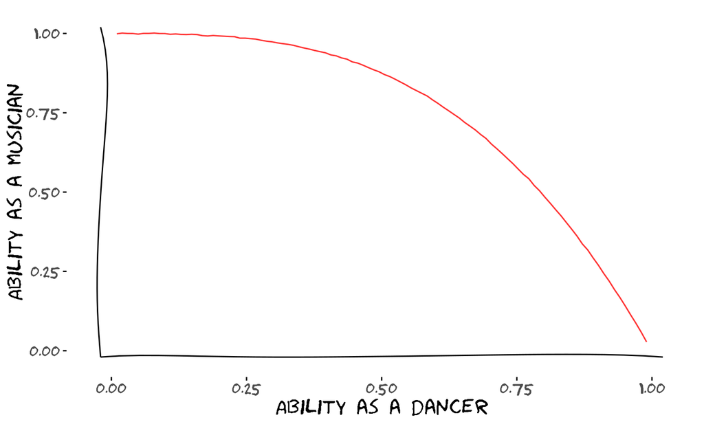

## Wrapping Up

- Complete the [knowledge check](https://goo.gl/forms/1XOfCyiJ6Jt1NR8J3) for today’s participation point.
- Please provide [feedback](https://goo.gl/forms/8SiOwdi19kN8cINJ3) on today’s lecture.